# 第13回 次のトークンと注意（自己回帰・注意機構・大規模言語モデル・最新の日本語 LLM）

経済データとプログラミングII

第13回

次のトークンと注意（LLM）

次の語を予測し、前の語を重く見て、積み重ねる

経済データとプログラミングII

第13回 — Topic01

自己回帰と次トークン予測

次の語は、どう予測する？

## 第13回の道のり

1

次を予測する

実習：実行 準備と白書の読み込み

実習：実行 日報 3 行の次の語

実習：実行 白書の物価の次

実習：実行 直前 1 語の続き

2

重く見る

実習：実行 3 語の注意

3

積み重ねる

実習：実行 モデルの読み込み

実習：実行 次の語の上位 5

実習：実行 続きの文

4

大きくする

大きさの比べ・  
たしかめ

興味のある人だけ：  
最新のモデル

いまココ。次の語を、数えて予測する

## 前の回の振り返り

前に持った道具

Q: 先を予測する道具と、言葉を扱う道具は、何だったか

- **多段予測**：予測した値を窓の右端に入れて、また予測した（前に出てきた）
- **区切って数える**：文を語に区切り、`Counter` で数えた（前の回）
- **語を点にする**：語を 2 つの数で点にし、掛けて足して近さを測った（前の回）

今日は、数ではなく「次の語」を予測する

## このトピックで学ぶこと

- **ここまで**：時系列なら、過去の値から次の値を予測できた
- **でも**：毎日使う AI は、数ではなく文章を書く  
  スマホの予測変換も、打った語の「次の語」を出してくる
- **問い**：**文章でも「次に何と書くか」を予測できないか**
- **進め方**：前半はお店の日報 3 行、後半で経済財政白書

次の語を予測できれば、それを足して、続きの文が書ける

## 準備と白書の読み込みのセル

```python
!pip install -q sudachipy sudachidict-core==20260428 sentencepiece
import numpy as np
import pandas as pd
from collections import Counter
from sudachipy import Dictionary, SplitMode
```

```python
BASE = "ここに manaba の URL を貼る"
wp = pd.read_csv(BASE + "whitepaper_text.csv")
print(len(wp))
```

**先に書き換える**：`BASE` の中を、manaba の URL の最後の `/` まで  
（例 `"https://…/data/"`）

**道具**：区切る道具は前の回と同じ  
`sentencepiece` は、このあとのトピックで使う AI の部品（いまは入れておくだけ）

**出力**：`348` は経済財政白書の段落の数（前の回と同じデータ）

⏸ PAUSE 動画を止めてセルを 2 つ実行。`348` が出たら再生に戻る

## お店の日報 3 行

|  | 日報 | 区切った語 |
| --- | --- | --- |
| A | 売上が増えた。 | 売上｜が｜増え｜た｜。（5 個） |
| B | 売上は増えていない。 | 売上｜は｜増え｜て｜い｜ない｜。（7 個） |
| C | 客足が減った。 | 客足｜が｜減っ｜た｜。（5 個） |

前の回と同じ 3 行。5 ＋ 7 ＋ 5 ＝ 17 個の語に区切れる  
今度は「ある語の、すぐ後ろに来た語」を数える

## ★ 次に来た語の数え上げ

[figure not shown]

後ろに来た語を数えて、合計で割る。足すと 1 になる

## ◼ 次の語の確率

定義

$$\text{次の語の確率} = \frac{\text{A の後ろに B が来た回数}}{\text{A の後ろに語が来た回数}}$$

A：いま見ている語。B：その次に来るかもしれない語

今回は

売上 → が ＝ $\dfrac{1}{2}$、売上 → は ＝ $\dfrac{1}{2}$

売上の後ろは 2 回

いちばん確率の高い語を、次の語の予測にする  
同点なら、先に数えた語（ここでは「が」）

## 日報 3 行の次の語のセル

```python
tok = Dictionary().create()
def kugiru(text):
    return [m.surface() for m in tok.tokenize(text, SplitMode.C)]
def tsugi_wo_kazoeru(bunsho):
    tsugi = {}
    for text in bunsho:
        t = kugiru(text)
        for a, b in zip(t, t[1:]):
            tsugi.setdefault(a, Counter())[b] += 1
    return tsugi
shop = ["売上が増えた。", "売上は増えていない。", "客足が減った。"]
tsugi_shop = tsugi_wo_kazoeru(shop)
print(tsugi_shop["売上"])
print(tsugi_shop["が"])
print(tsugi_shop["た"])
```

| 1-3 | **区切る** `kugiru` | 文 → 語の並び（前の回と同じ） |
| --- | --- | --- |
| 4-8 | **隣の組を作る** `zip` | 文の並び → （売上, が）（が, 増え）… |
| 9-10 | **組ごとに 1 足す** | 組 → すぐ後ろに来た語の数 |
| 11-15 | **見る** | 日報 3 行 → 売上・が・た の後ろの数 |

⏸ PAUSE  
動画を止めて実行  
売上 → が 1・は 1  
が出たら再生に戻る

## ◼ 自己回帰

**自己回帰：予測した語を足して、また次を予測する、の繰り返し**

[figure not shown]

前に出てきた多段予測と同じ形。自分の答えを、次の入力にする

## 2 つ前までの数え上げ

[figure not shown]

前をどこまで見るかで、予測が変わる

## ✋ たしかめ 物価の次の語

たしかめ

今度は白書 348 段落で、同じ数え方をする  
白書で「物価」の次にいちばん多く来た語は、どれか

**ⓐ** の **ⓑ** 上昇率 **ⓒ** が

⏸ PAUSE 動画を止めて 1 分。選んだら再生に戻る

## 白書の物価の次のセル

```python
tsugi_wp = tsugi_wo_kazoeru(wp["text"])
c = tsugi_wp["物価"]
print(sum(c.values()))
print(c.most_common(5))
```

| 行 | 部品 | 渡すもの | できるもの |
| --- | --- | --- | --- |
| 1 | **白書の次の語** | 348 段落 | 語ごとの「次に来た語」の数 |
| 2-4 | **物価の次を見る** | 「物価」 | 回数の合計と、多い順の 5 語 |

`tsugi_wo_kazoeru` は、「日報 3 行の次の語のセル」で作った関数（同じ数え方を白書にも使う）

⏸ PAUSE 動画を止めてセルを実行。`277` が出たら再生に戻る

## たしかめの答え

答えは **ⓑ 上昇率**（277 回のうち 141 回）

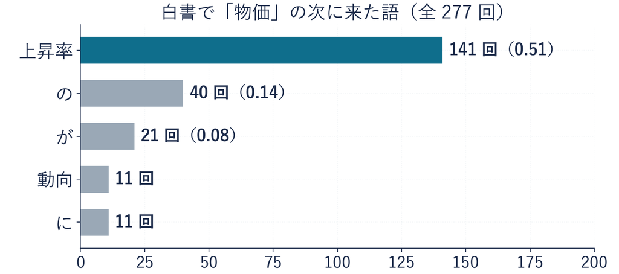

「物価」の次の語の確率は、上昇率が約 0.51。白書は「物価上昇率」の話が多い

## 直前 1 語の続きのセル

```python
def tsuzukeru(w, n=14):
    out = [w]
    for _ in range(n):
        w = tsugi_wp[w].most_common(1)[0][0]
        out.append(w)
    return "｜".join(out)
print(tsuzukeru("賃金"))
print(tsuzukeru("景気"))
print(tsuzukeru("日本"))
```

| 行 | 部品 | 渡すもの | できるもの |
| --- | --- | --- | --- |
| 1-3 | **用意** | 書き出しの語 `w` | 並びの頭と 14 回のくり返し |
| 4 | **次を選ぶ** | いまの語 `w` | いちばん多い次の語 |
| 5-6 | **足す（自己回帰）** | 選んだ語 | 選んだ語が次の `w`・14 語足した並び |
| 7-9 | **見る** | 賃金・景気・日本 | 3 本の続き |

⏸ PAUSE 動画を止めてセルを実行。3 行の続きが出たら再生に戻る

## ★ 3 つの書き出しの同じ鎖

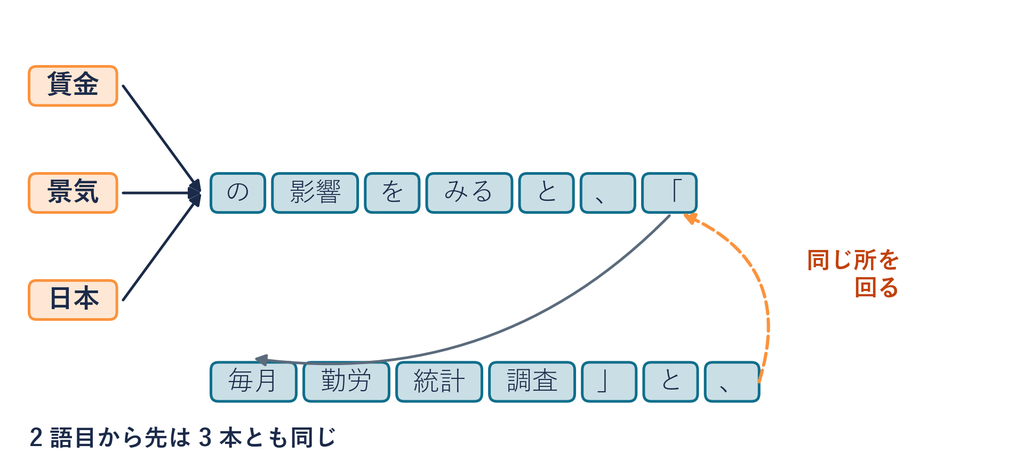

直前の 1 語しか見ないので、書き出しが何だったかを忘れる

## 白書に 1 回しか出ない並び

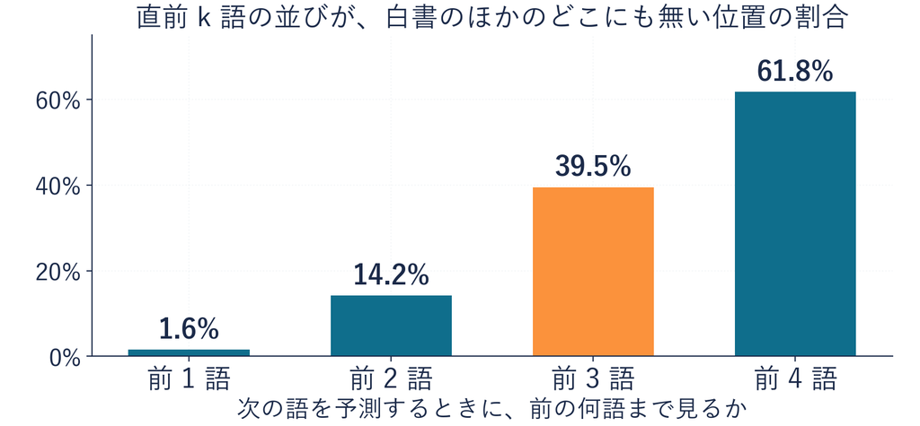

**0 回**：「賃金の影響」（前のページの鎖の頭）の 3 語の並びは、白書に 1 回も無い  
数えられないので、次の語を出せない

**1 回だけ**：語の並びは、長くするとほとんど二度と出てこない  
1 回だけの並びは、その 1 か所の続きを丸写しするだけで、頼れる割合にならない

## まとめ

- **次の語の確率**：ある語の後ろに、それぞれの語が来た割合
- **自己回帰**：予測した語を足して、また次を予測する、の繰り返し
- **数える方法の限界**：直前 1 語では書き出しを忘れ、  
  前の数語まで見ると数える相手がいない

**残った問い**：数えるのをやめて、前の語を全部使って予測できないか  
これを次のトピックで見る

経済データとプログラミングII

第13回 — Topic02

注意機構

前の語のどれを、どれだけ重く見る？

## 第13回の道のり

1

次を予測する

実習：実行 準備と白書の読み込み

実習：実行 日報 3 行の次の語

実習：実行 白書の物価の次

実習：実行 直前 1 語の続き

2

重く見る

実習：実行 3 語の注意

3

積み重ねる

実習：実行 モデルの読み込み

実習：実行 次の語の上位 5

実習：実行 続きの文

4

大きくする

大きさの比べ・  
たしかめ

興味のある人だけ：  
最新のモデル

いまココ。前の語のどれを、どれだけ重く見るか

## このトピックで学ぶこと

- **ここまで**：次の語は、数えた割合で予測できた
- **でも**：直前 1 語では書き出しを忘れ、前の数語まで見ると数える相手がいない
- **問い**：**数えるのをやめて、前の語を全部使って予測したい**
- **進め方**：前半は 3 語の小さな例、後半で本物の AI の中を見る

語を前の回の点（2 つの数）で表せば、数えなくても計算できる  
前の語を全部読む機械は、もう前に出てきている

## 3 語の 2 つの数

[figure not shown]

**2 つの数**：横：お金の話らしさ、縦：背丈の話らしさ（説明のために手で置いた数）

**高い (1, 1)**：値段にも背丈にも使う語なので、両方に 1

**読み方**：この 3 語を、2 通りのやり方で読んで比べる

## ★ 順に読む機械での 3 語の読み

前に出てきた、順に読む機械。前のメモを半分にして、いま読んだ点を足す

[figure not shown]

最後のメモ (2, 1) が、「高い」まで読んだ要約（前に出てきた隠れ状態）

## ★ メモの中身と順番で決まる重み

[figure not shown]

この機械では、重さが順番だけで決まり、語の中身を見ていない

## ★ 同じ文の 2 通りの読み方

重みを順番でなく、話題の合い方で決める

[figure not shown]

順に読む機械も混ぜる（3 語の価格の文 (2, 1)・山の文 (1, 3/2)）。違うのは重みの決め方だけ

## 段 0 一致度

いま読む「高い」から、前の語と自分へ線を引き、線ごとに掛けて足す

[figure not shown]

割らないので、話の向きが合い、その話が強いほど大きい（価格は自分より大きい）

## 段 1 注目の割合

[figure not shown]

**足して 1**：平均と同じく、混ぜた点が、並べた語の点のあいだに入る

**「が」が 0**：一致度 0 なので、割合も 0（混ぜ物に入らない）

**決めた所**：割合の出し方は、そう決めた。本物の AI は、大きい一致度ほど強めてから割る

## 段 2・3 掛け算と足し算

[figure not shown]

混ぜた「高い」は (3, 1/3)。お金の話の「高い」になった

## ◼ 注意

**注意：話題が合い、その話が強い語ほど重くして混ぜる**

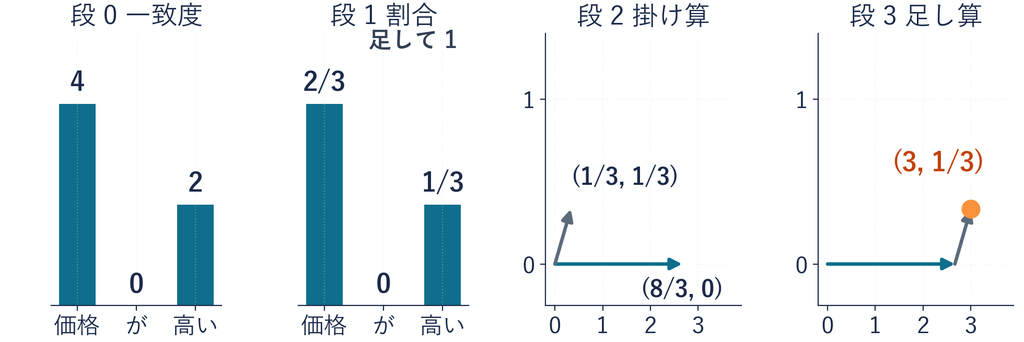

一致度 → 割合 → 掛け算 → 足し算。割合は、その文を読むたびに計算し直す

ことばの式

**一致度**＝ いま読む語の横 × 並べた語の横 ＋ いま読む語の縦 × 並べた語の縦

**割合**＝ 一致度 ÷ 一致度の合計

**混ぜた点**＝ 各語の点 × 割合 を、全部足したもの

## ✋ たしかめ 山の文の混ぜた結果

たしかめ

「山 が 高い」で、山を (0, 2) とする  
混ぜたあとの「高い」は、どちら寄りか

**ⓐ** お金 **ⓑ** 背丈 **ⓒ** ちょうど半々

⏸ PAUSE 動画を止めて 1 分。選んだら再生に戻る

## たしかめの答え

一致度

山 $0 \times 1 + 2 \times 1 = 2$、が 0、高い 2

割合

合計 4 で割る：$\dfrac{1}{2}$、$0$、$\dfrac{1}{2}$

足して 1

掛けて足す

$(0, 2) \times \dfrac{1}{2} + (0, 0) \times 0 + (1, 1) \times \dfrac{1}{2} = (\dfrac{1}{2}, \dfrac{3}{2})$

答えは **ⓑ 背丈**（横 1/2 ＜ 縦 3/2）

**自分を並べないと**：価格の文は (4, 0)（価格そのもの）、山の文は (0, 2)（山そのもの）

**自分を並べると**：自分の割合があるので、「高い」の中身も残る

## ★ 同じ「高い」の 2 つの点

**注意：同じ語でも、前の語の混ぜ方で、別の点になる**

[figure not shown]

前の回の「高い」は、どの文でも同じ 1 点のままだった。それが、ここで動いた  
お金寄りなら値段の話の語を、背丈寄りなら山の話の語を、次に予測しやすくなる

## 決まった数と文ごとの割合

決まっていて、変えないもの

各語の 2 つの数  
（価格 (4, 0)・高い (1, 1)）  
一致度の測り方  
（掛けて足す）

文ごとに変わるもの

その文の中で計算した割合だけ  
（「高い」自身の割合は  
価格の文で 1/3、山の文で 1/2）

2 つの文で、数は一度も変えていない。使うたびに学習し直してはいない

## ★ 注意がうまくいくわけ

[figure not shown]

**遠さ**：遠いだけでは薄まらない（この例では、何個挟んでも 2/3）

**待たない**：練習のとき、どの語の線も一度に計算できる。だから大量の文で練習できる

**引き換え**：語の順番を見ない（次のトピックの位置の印で手当てする）  
語が増えると線が増える（語が 10 個で 55 本、1,000 個で約 50 万本）

## 本物の AI の注意の割合

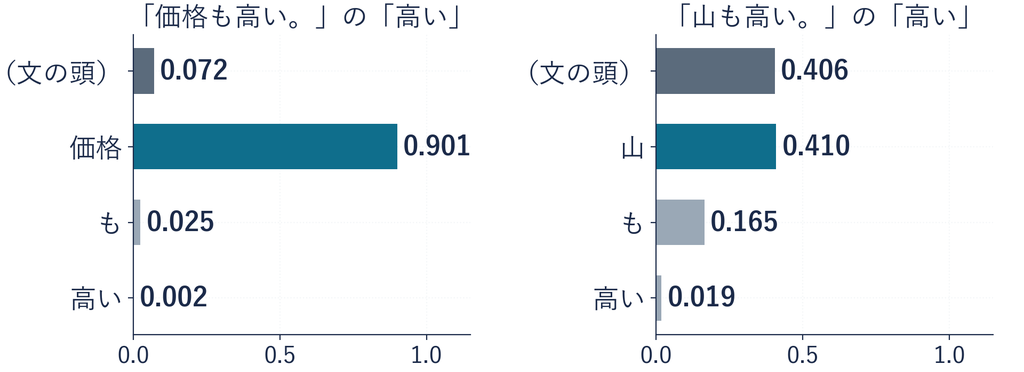

**モデル**：あとで動かすモデル（12 段）の、入口から 3 段目・11 番目の見方

**「も」の文**：このモデルは「が高い」を 1 つに区切るので、「も」の文で測った

**読み**：価格の文は価格に 0.90、山の文は山に 0.41（文の頭にも同じくらい）

## 割合の読み方の注意

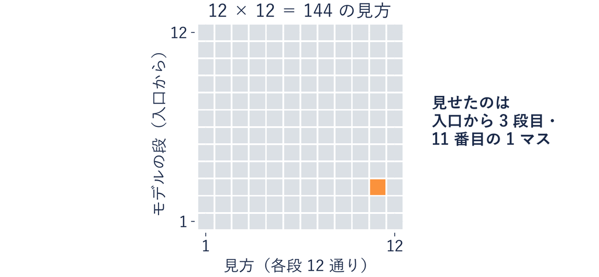

**見方は 144 通り**：見せたのは、その 1 つだけ

**42 文で試す**：名詞への割合は平均 0.70、最小 0.03。名詞が首位は 32 文

**理由ではない**：割合は「どこから数を集めたか」。判断の理由の証拠ではない

## 3 語の注意のセル

```python
kazu = {"価格": [4, 0], "山": [0, 2], "が": [0, 0], "高い": [1, 1]}
def chui(words):
    X = np.array([kazu[w] for w in words])
    itchi = X @ X[-1]
    wariai = itchi / itchi.sum()
    kakeru = X * wariai[:, None]
    mazeta = kakeru.sum(axis=0)
    print("文:", " ".join(words))
    print("一致度:", itchi.tolist())
    print("割合:", wariai.round(3).tolist())
    print("掛け算:", kakeru.round(3).tolist())
    print("混ぜた「高い」:", mazeta.round(3).tolist())
    return mazeta
kakaku = chui(["価格", "が", "高い"])
yama = chui(["山", "が", "高い"])
```

⏸ PAUSE 動画を止めて実行  
混ぜた「高い」が `[3.0, 0.333]` と `[0.5, 1.5]` なら再生に戻る

## デモ：注意の実験室

タブ

注意：一致度（掛けて足す）→ 割合（一致度 ÷ 合計）→ 掛け算 → 足し算。  
数は説明のために手で置いた例

- **何を見るか**：最初の語を替えると  
  混ぜた「高い」の点がお金寄り・背丈寄り・ちょうど半々に分かれるか
- **図の意味**：表は各語の数・一致度・割合・掛け算と、その合計（足し算の結果）  
  平面は横がお金の話らしさ、縦が背丈の話らしさ  
  青い点が「高い」、橙の点が混ぜた「高い」
- **操作**：最初の語のボタン 5 つ（価格・山・が・物価・背）  
  ほかに「次の段」「全部の段」「『高い』も並べる」・戻す

ミッション 混ぜた「高い」がちょうど半々のままになる語を探す

※ 次のスライドへ進むときは、デモの枠の外を一度クリックしてから ← → キーを押す

[interactive chart not shown]

## まとめ

- **一致度**：いま読む語と、  
  並べた語の 2 つの数どうしを掛けて足した値
- **注目の割合**：一致度を、足して 1 になる割合に直したもの
- **注意**：話題が合い、その話が強い語ほど重くして混ぜる
- **授業の外で**：翻訳で「高い」  
  を *expensive* と *tall* に訳し分けるのは、この混ぜ方

**残った問い**：本物の AI は、この数をだれが決め、どうやって長い文を書き続けるのか  
これを次のトピックで見る

経済データとプログラミングII

第13回 — Topic03

大規模言語モデル

毎日使う AI の中身は何だった？

## 第13回の道のり

1

次を予測する

実習：実行 準備と白書の読み込み

実習：実行 日報 3 行の次の語

実習：実行 白書の物価の次

実習：実行 直前 1 語の続き

2

重く見る

実習：実行 3 語の注意

3

積み重ねる

実習：実行 モデルの読み込み

実習：実行 次の語の上位 5

実習：実行 続きの文

4

大きくする

大きさの比べ・  
たしかめ

興味のある人だけ：  
最新のモデル

いまココ。注意を積み重ねた、本物の AI

## このトピックで学ぶこと

- **ここまで**：注意で、前の語を割合で混ぜられた
- **でも**：3 語の点（語ごとに 2 つの数）は、説明のために手で置いた
- **問い**：毎日使う AI は、だれがその数を決め、  
  どうやって長い文を書き続けるのか
- **進め方**：本物の小さなモデルを、手元で動かして中身を見る

本物の AI も、次の語の確率を出している

## ★ 本物の AI の次の語の確率

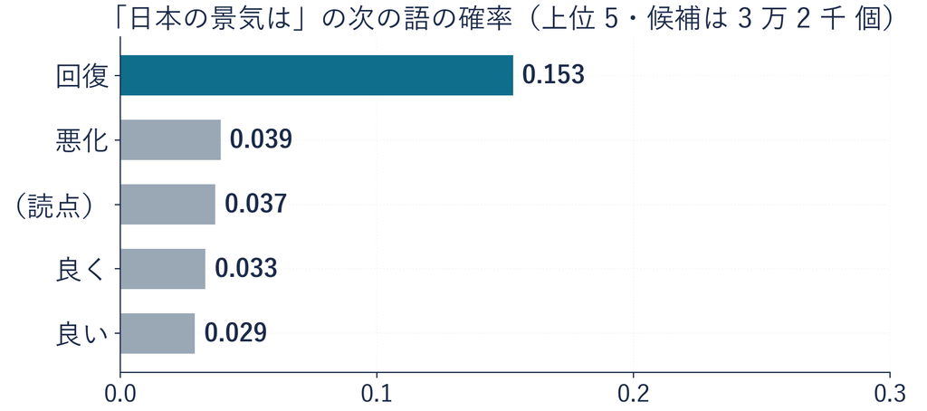

**モデル**：日本語の小さな AI（rinna の japanese-gpt2-small・1.1 億パラメータ）  
毎日使う AI は、これよりずっと大きい

**パラメータ**：モデルの中で、練習で決まる数。前のトピックで手で置いた数の仲間

**読み**：前に白書で数えた割合と同じ形の棒。候補は 3 万 2 千個の語のかけら  
（かけら：モデルが決めた区切り。語より短いことも、まとまることもある）

## 白書の鎖と本物の AI の続き

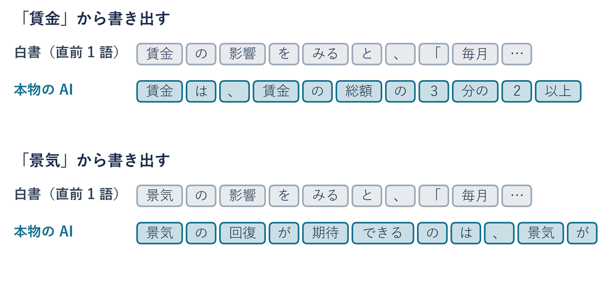

本物の AI は、書き出しの語を忘れない。前の語を全部並べて、注意で混ぜているから

## 後ろを見ない書き方

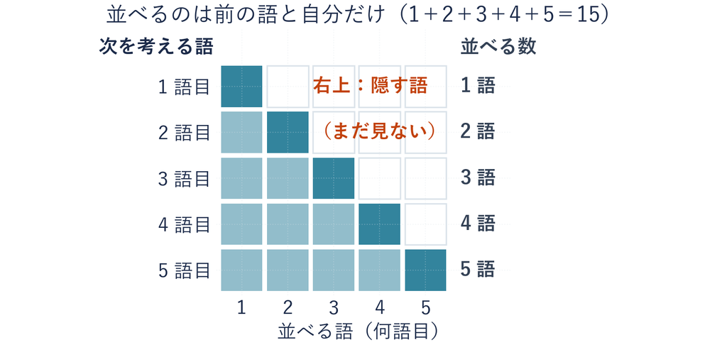

**並べる語**：前の語と自分だけ。前のトピックで「高い」を最後の語にしたのと同じ

**わけ**：練習では文が全部手元にある  
後ろを隠さないと、答えを見ながら予測する練習になる  
前に出てきた「未来を混ぜた点数は、予測する力を測っていない」と同じ

## 位置の印

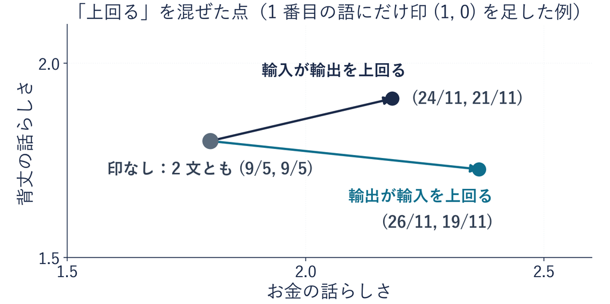

**困ること**：2 文は同じ語で、意味は逆  
注意は順番を見ないので、印が無いと同じ点になる  
（輸出 (3, 1)・輸入 (1, 3)・上回る (1, 1)。説明のために手で置いた数）

**位置の印**：何番目の語かを表す数。語の点に足しておくと、2 文が分かれる  
本物はどの位置にも違う印を足す（図は 1 番目だけの例）

## ◼ Transformer

[figure not shown]

用語

**Transformer**：入口で語の点に位置の印を足し  
注意とニューロンの層の 1 段を何段も積んだ機械

前に「遠い昔を直接見に行く仕組みがある」と言った。それが注意で、  
注意を積んだ機械が Transformer

## ◼ 大規模言語モデル

大規模言語モデル：注意を積んで、  
大量の文で次の語の予測を練習した機械

用語

**事前学習**：大量の文章で「次の語を予測する」練習を先にしておくこと

[figure not shown]

正解の次の語は文章に書いてある。直すのは、語の点と一致度の計算に使う数

## モデルの読み込みのセル

```python
import torch
from transformers import AutoTokenizer, AutoModelForCausalLM
NAME = "rinna/japanese-gpt2-small"
REV = "f7fdefe2941d9629a7b2894564435e0e035df6a6"
mtok = AutoTokenizer.from_pretrained(NAME, revision=REV)
model = AutoModelForCausalLM.from_pretrained(NAME, revision=REV)
print(sum(p.numel() for p in model.parameters()))
```

| 行 | 部品 | 渡すもの | できるもの |
| --- | --- | --- | --- |
| 1-2 | **道具** | — | モデルを読む道具 |
| 3-4 | **名前と版** | モデルの名前・版 | いつも同じモデル |
| 5-6 | **読み込む** | 名前と版 | 区切りの道具 `mtok`・モデル `model` （約 0.46 GB） |
| 7 | **見る** | — | パラメータの個数 110,418,432 （約 1.1 億） |

⏸ PAUSE 動画を止めて実行。英語の注意書きは出てよい。`110418432` が出たら再生に戻る

## 次の語の上位 5 のセル

```python
def tsugi5(m, t, text):
    enc = t(text, return_tensors="pt", add_special_tokens=False)
    with torch.no_grad():
        p = torch.softmax(m(**enc).logits[0, -1].float(), dim=-1)
    v5, i5 = torch.topk(p, 5)
    return [(t.decode([int(i)]), round(float(v), 3)) for v, i in zip(v5, i5)]
print(tsugi5(model, mtok, "日本の景気は"))
```

| 行 | 部品 | 渡すもの | できるもの |
| --- | --- | --- | --- |
| 2 | **区切る** | 書き出しの文 | 語のかけらの番号 |
| 3-4 | モデルに通して 確率にする | 番号 （最後の語の所 `[0, -1]`） | 次の語の確率（足して 1） |
| 5-6 | **上位を選ぶ** | 確率 | 上位 5 語と確率 |
| 7 | **見る** | 「日本の景気は」 | 回復 0.153 が 1 位 |

`add_special_tokens=False`：文の終わりの印を勝手に付けない（わけは付録）

⏸ PAUSE 動画を止めて実行。回復 0.153 が 1 位なら再生に戻る

## 続きの文のセル

```python
def kaku(m, t, text, n=10):
    enc = t(text, return_tensors="pt", add_special_tokens=False)
    out = m.generate(**enc, max_new_tokens=n, do_sample=False,
                     pad_token_id=t.eos_token_id)
    new = out[0, enc["input_ids"].shape[1]:]
    return text + " → " + "｜".join(t.decode([int(i)]) for i in new)
print(kaku(model, mtok, "日本の景気は"))
print(kaku(model, mtok, "賃金"))
print(kaku(model, mtok, "景気"))
```

| 行 | 部品 | 渡すもの | できるもの |
| --- | --- | --- | --- |
| 2-4 | **続けて書く** | 書き出し | いちばん確率の高い語を 10 回足した並び |
| 5-6 | **足した所だけ** | 並び | 「書き出し → 続き」の文字 |
| 7-9 | **見る** | 3 つの書き出し | 1 行目は 日本の景気は → 回復｜し ｜、｜雇用｜も… |

⏸ PAUSE 動画を止めて実行。3 行の続きが出たら再生に戻る

## ✋ たしかめ 物価の次の語

たしかめ

白書を数えたときは、「物価」の次は上昇率が 5 割だった  
本物の AI で、「物価の」の次にいちばん確率の高い語は、どれか

**ⓐ** 上昇 **ⓑ** 高騰 **ⓒ** 安い

⏸ PAUSE 動画を止めて 1 分。選んだら再生に戻る

## たしかめの答え

答えは **ⓑ 高騰**（0.256）

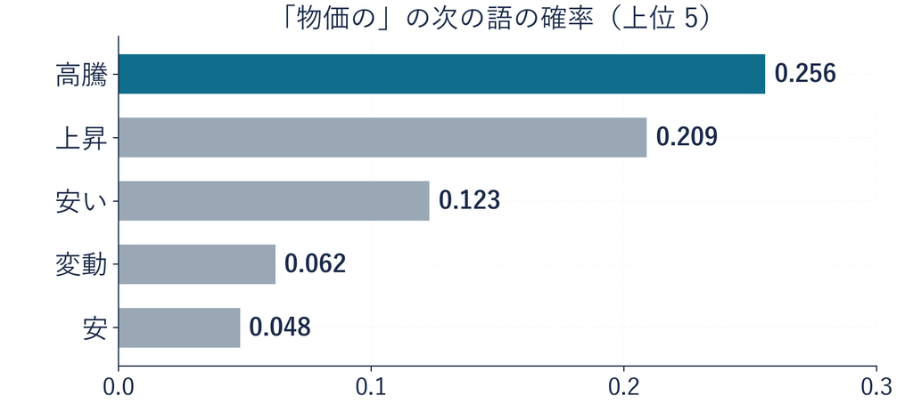

**続き**：物価の → 高騰や、海外からの観光客の増加により、…

**読み**：この AI は白書ではなく、ウィキペディアなどネットの日本語の文章で練習した  
練習した文章が違えば、次の語も変わる。機械がしているのは、次の語の予測だけ

## ★ 毎日使う AI の部品

[figure not shown]

前に出てきた「毎日使う AI チャットの中身」は、この秋に学んだ道具の組み合わせ  
（毎日使う AI チャット：ChatGPT・Gemini・Claude など）

## 丸暗記と練習の違い

白書の鎖

数えた隣どうしの組しか使えない  
丸暗記に近い

大規模言語モデル

大量の文で次の語の  
予測を練習した  
初めて見る書き出しにも、  
続きを出せる

ただし、続きが正しいとは限らない。確率の高い語を選んでいるだけ

## まとめ

- **Transformer**：入口で語の点に位置の印を足し、  
  注意とニューロンの層の 1 段を何段も積んだ機械
- **事前学習**：大量の文章で、  
  次の語を予測する練習を先にしておくこと
- **大規模言語モデル**：注意を積んで、  
  大量の文で次の語の予測を練習した機械

**残った問い**：このモデルは「日本の景気は」から、回復し、  
雇用も回復し、雇用も…と繰り返す  
毎日使う AI は、もっと大きい。  
大きくすると何が変わるのか。これを次のトピックで見る

経済データとプログラミングII

第13回 — Topic04

最新の日本語 LLM

大きくすると、何が変わる？

## 第13回の道のり

1

次を予測する

実習：実行 準備と白書の読み込み

実習：実行 日報 3 行の次の語

実習：実行 白書の物価の次

実習：実行 直前 1 語の続き

2

重く見る

実習：実行 3 語の注意

3

積み重ねる

実習：実行 モデルの読み込み

実習：実行 次の語の上位 5

実習：実行 続きの文

4

大きくする

大きさの比べ・  
たしかめ

参考 興味のある人だけ：  
最新のモデル

いまココ。同じ問いを、最新の大きなモデルに

## このトピックで学ぶこと

- **ここまで**：小さいモデルでも、書き出しを忘れずに次の語を予測し続けられた
- **でも**：同じ言い回しを繰り返した。毎日使う AI は、もっと大きい
- **問い**：**大きくすると、何が変わるのか**
- **進め方**：同じ書き出しを同じ形で入れて、最新の大きなモデルと並べる

**比べるときに変えてよいのは、モデルだけ**

## ◼ パラメータ数

**パラメータ数：学習で決める重みとバイアスの、全部の個数**

重みとバイアス：前に出てきたニューロンの層で、掛ける数と足す数。  
モデルの大きさは、この数がいくつあるかで測る

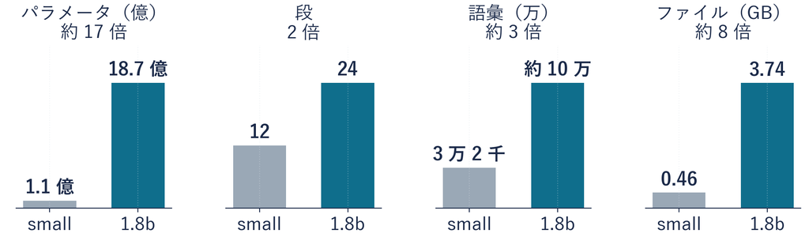

**2 つのモデル**：small（前のトピックの小さいモデル）と  
国立情報学研究所の llm-jp-3.1-1.8b（b は 10 億。約 18 億）

**語彙**：AI が使う語と語のかけらの一覧の数

**読み**：パラメータは約 17 倍。毎日使う AI は、これよりさらに大きい  
ファイルが約 8 倍にとどまるわけは付録に

## ★ 同じ問いの続き

[figure not shown]

「日本の景気は」では、1 位はどちらも回復。違ったのは、その先の続け方

良かったのは大きなモデル：同じ言い回しに戻らず、文を閉じた  
わけの候補：決める数が約 17 倍・段が 2 倍で、続け方を細かく持てる

練習した文章や区切り方も違うので、大きさだけの効き目とは言い切れない（詳しくは付録）

## ✋ たしかめ 大きいモデルの物価の次

たしかめ

小さいモデルでは、「物価の」の次は高騰だった  
1.8b で、「物価の」の次にいちばん確率の高い語は、どれか

**ⓐ** 高騰 **ⓑ** 変動 **ⓒ** 上昇

⏸ PAUSE 動画を止めて 1 分。選んだら再生に戻る

## たしかめの答え

答えは **ⓑ 変動**（0.341）

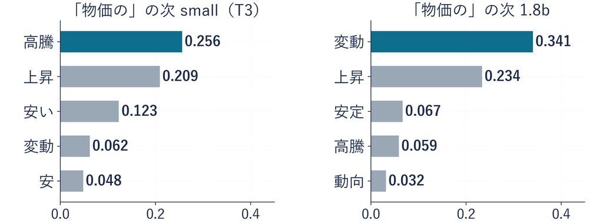

同じ書き出しでも、モデルが違えば次の語が変わる

## 毎日使う AI の共通の土台

[figure not shown]

**GPT**：OpenAI。人が答えを比べた評価で仕上げるやり方を、論文で公開  
参照した技術報告では、大きさは公表されていない

**Gemini**：Google。最初から、文章・画像・音声・動画をいっしょに扱うように作った、と説明している

**Claude**：Anthropic。人の評価に加えて、守ってほしい原則を書いた文書でも仕上げる、と説明している

土台の考え方は同じ。中の作り（層の数・大きさ・部品）は会社ごとに違い、多くは公表されていない  
違いは、中の作り・練習させた文章・仕上げのしかた（詳しい表と出典は付録）

## 参考 最新のモデルのコード

参考：やってみたい人だけ。配布のノートには入っていない  
やるなら、ノートの最後に新しいセルを作って書き写す。3.74 GB と重いので、やらなくてよい

```python
NAME_L = "llm-jp/llm-jp-3.1-1.8b"
REV_L = "4ff5880c4de1cff97be961bc704cba61ceeb4d5d"
ltok = AutoTokenizer.from_pretrained(NAME_L, revision=REV_L)
lmodel = AutoModelForCausalLM.from_pretrained(
    NAME_L, revision=REV_L, dtype=torch.bfloat16)
print(sum(p.numel() for p in lmodel.parameters()))
```

```python
for q in ["日本の景気は", "アルバイトの時給が", "物価の"]:
    print(q, tsugi5(lmodel, ltok, q))
print(kaku(lmodel, ltok, "日本の景気は", n=6))
```

前のトピックの関数 `tsugi5`・`kaku` を、そのまま大きなモデルに渡す（変えるのはモデルだけ）

## まとめ

- **パラメータ数**：学習で決める重みとバイアスの、全部の個数
- **モデルの違い**：同じ書き出しでも、  
  1 語目も、その先の続け方も変わる  
  （物価の は 1 語目から、日本の景気は は続け方が）

**授業の外で**：AI はもっともらしい次の語を選ぶだけで、事実かは確かめていない  
レポートやゼミで AI が出した数字や出典は、自分で確かめてから使う

## 第 13 回のまとめ

[figure not shown]

毎日使う AI は、新しい語を 1 つ書くたびに、  
前の語のどれを重く見るかを計算し直しながら  
次の語を予測し続けている。  
時系列で次の値を予測したのと同じ仕事を、言葉でしている